# Upset plot w/ cytokines expressed in bulk and single nuclei data

Juliana Beker Godoy, MSc Graduate Program in Bioinformatics Professional and Technological Education Sector Federal University of Parana (UFPR) Curitiba, Brazil

2025-05-27

> Bulk RNAseq: 1,210 unique samples | Single-nuclei RNAseq: 424 unique samples (subset) | Brain region: DLPFC | ROSMAP cohort

```r
# This R object was created during test T016
# Character vector containing gene symbols from expressed genes in bulk data
file_path <- file.path("C:/Users/beker/OneDrive/Documentos/Mestrado/GitHub/Cytokines/bulk_RNAseq/T016/list_expr_bulk_T016.RData")
# Load object
load(file_path)
```

```r
# This R object was created during test T018
# List of gene symbols for expressed genes in each cell type of single nuclei data
file_path <- file.path("C:/Users/beker/OneDrive/Documentos/Mestrado/GitHub/Cytokines/sn_RNAseq_DLPFC/T018/list_expr_sn_T018.RData")
# Load object
load(file_path)
```

# Upset plot

Expressed cytokines genes in the DLPFC region using bulk and single nuclei RNA-seq data

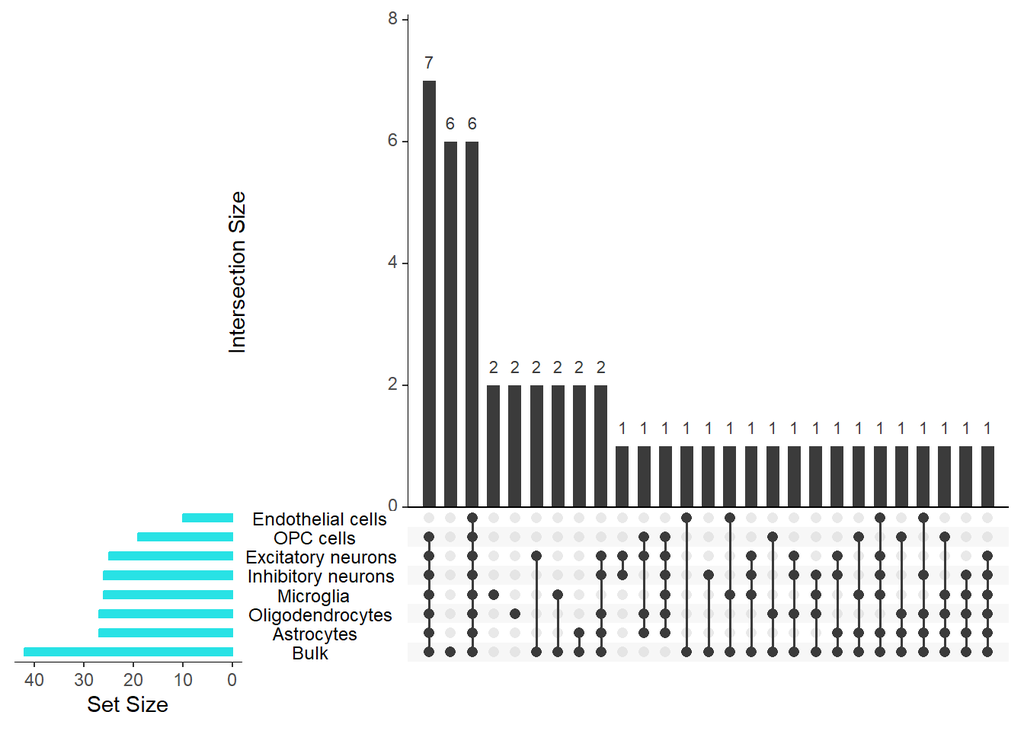

```r
# Upset plot
upset_plot <- upset(
  fromList(list_expr_merged),
  order.by = "freq",
  sets.bar.color = 5,
  nsets = 8,
  text.scale = 1.3
)

print(upset_plot)
```

# Analysis

### Cortex

The following cytokines were expressed in the cortex (bulk + sn) of ROSMAP participants:

```r
merged_list <- unlist(list_expr_merged)
cytokines_unique <- unique(merged_list)
total_cytokines_cortex <- length(cytokines_unique)
print(total_cytokines_cortex)
```

```
## [1] 49
```

```r
print(cytokines_unique)
```

```
##  [1] "CX3CL1"   "IL32"     "DCN"      "IGF1"     "HGF"      "KITLG"
##  [7] "CXCL2"    "THPO"     "FLT3LG"   "IL11"     "TNFSF13B" "EBI3"
## [13] "TGFB1"    "C5"       "CCL2"     "VEGFA"    "TNFSF4"   "SPP1"
## [19] "TNFSF10"  "IL1B"     "PSPN"     "TNFSF9"   "C3"       "IL33"
## [25] "FGF2"     "EGF"      "CXCL14"   "CTF1"     "IL18"     "CCL28"
## [31] "IL34"     "TNFSF13"  "CXCL5"    "IL15"     "GDNF"     "IL12A"
## [37] "CXCL8"    "IL16"     "IL17D"    "NOG"      "CSF1"     "TNFSF12"
## [43] "CXCL13"   "IL7"      "CXCL17"   "IL1A"     "TNFSF8"   "IFNA13"
## [49] "IFNA2"
```

### Bulk data

The following cytokines were exclusively expressed in the bulk data and do not appear in the single nuclei list:

```r
# Getting unique genes expressed in bulk data
bulk_unique_genes <- setdiff(list_expr_merged$Bulk, unlist(list_expr_merged[-1]))
print(bulk_unique_genes)
```

```
## [1] "CXCL2" "IL11"  "CCL2"  "CXCL5" "IL12A" "CXCL8"
```

### Bulk and single nuclei

The following cytokines are expressed both in the bulk and single nuclei data (at least one cell type):

```r
# Expressed genes in bulk data
genes_bulk <- list_expr_merged$Bulk
# Genes expressed in at least one cell type in single nuclei data.
genes_cell_type <- unlist(list_expr_merged[-1])
# Intersection of genes expressed in bulk RNAseq and single nuclei RNAseq datasets
genes_bulk_and_cell_type <- intersect(genes_bulk, genes_cell_type)
# Expressed genes both at bulk and single nuclei data
print (genes_bulk_and_cell_type)
```

```
##  [1] "CX3CL1"   "IL32"     "DCN"      "IGF1"     "HGF"      "KITLG"
##  [7] "THPO"     "FLT3LG"   "TNFSF13B" "EBI3"     "TGFB1"    "C5"
## [13] "VEGFA"    "TNFSF4"   "SPP1"     "TNFSF10"  "IL1B"     "PSPN"
## [19] "TNFSF9"   "C3"       "IL33"     "FGF2"     "EGF"      "CXCL14"
## [25] "CTF1"     "IL18"     "CCL28"    "IL34"     "TNFSF13"  "IL15"
## [31] "GDNF"     "IL16"     "IL17D"    "NOG"      "CSF1"     "TNFSF12"
```

### Only single nuclei

The following cytokines were exclusively expressed in the single nuclei data and do not appear in the bulk list:

```r
# Genes expressed in at least one cell type
genes_cell_type <- unlist(list_expr_merged[-1])

# Expressed genes in bulk data
genes_bulk <- list_expr_merged$Bulk

# Obtain genes exclusively expressed in the cell types and not in the bulk
sn_unique_genes <- setdiff(genes_cell_type, genes_bulk)

print(sn_unique_genes)
```

```
## [1] "CXCL13" "IL7"    "CXCL17" "IL1A"   "TNFSF8" "IFNA13" "IFNA2"
```

### All cell types and bulk

The following cytokines are expressed by all cell types:

```r
genes_microglia <- list_expr_merged$Microglia
genes_excitatory_neurons <- list_expr_merged$"Excitatory neurons"
genes_inhibitory_neurons <- list_expr_merged$"Inhibitory neurons"
genes_astrocytes <- list_expr_merged$Astrocytes
genes_opc_cells <- list_expr_merged$"OPC cells"
genes_endothelial_cells <- list_expr_merged$"Endothelial cells"
genes_oligodendrocytes <- list_expr_merged$"Oligodendrocytes"

# Intersection
expr_all_data <- Reduce(intersect, list(genes_microglia, genes_excitatory_neurons, genes_inhibitory_neurons, genes_astrocytes, genes_opc_cells, genes_endothelial_cells, genes_oligodendrocytes))

print(expr_all_data)
```

```
## [1] "SPP1"    "FGF2"    "KITLG"   "CX3CL1"  "TNFSF12" "TGFB1"
```

### Only in oligodendrocytes

The following cytokines were exclusively expressed in oligodendrocytes:

```r
# Get genes expressed in oligodendrocytes
genes_oligodendrocytes <- list_expr_merged$"Oligodendrocytes"

# Filter to get genes expressed without oli
filtered_data <- unlist(list_expr_merged[-which(names(list_expr_merged) == "Oligodendrocytes")])

# Get genes expressed exclusively in oligodendrocytes
vip_cytokines_oli <- setdiff(genes_oligodendrocytes, filtered_data)

print(vip_cytokines_oli)
```

```
## [1] "IFNA13" "IFNA2"
```

### Only in microglia

The following cytokines were exclusively expressed in microglia:

```r
# Get expressed genes on microglia
genes_microglia <- list_expr_merged$Microglia

# Filter data to get all the expressed genes without microglia
filtered_genes <- unlist(list_expr_merged[-which(names(list_expr_merged) == "Microglia")])

# Get only the expressed genes on mic
vip_cytokines_mic <- setdiff(genes_microglia, filtered_genes)

print(vip_cytokines_mic)
```

```
## [1] "IL1A"   "TNFSF8"
```

### Only in neurons

The following cytokines were exclusively expressed in excitatory and inhibitory neurons:

```r
# Get expressed genes in ext
genes_excitatory_neurons <- list_expr_merged$"Excitatory neurons"

# Get expressed genes in inh
genes_inhibitory_neurons <- list_expr_merged$"Inhibitory neurons"

# Filter data without ext, inh
filtered_data <- unlist(list_expr_merged[-which(names(list_expr_merged) %in% c("Excitatory neurons", "Inhibitory neurons"))])

# Get expressed genes only expressed in neurons
vip_cytokines_neurons <- setdiff(intersect(genes_excitatory_neurons, genes_inhibitory_neurons), filtered_data)

print(vip_cytokines_neurons)
```

```
## [1] "CXCL13"
```

### Bulk and excitatory neurons

The following cytokines were exclusively expressed in the bulk and excitatory neurons:

```r
# Get expressed genes in bulk
genes_bulk <- list_expr_merged$Bulk

# Get expressed genes in ext
genes_excitatory_neurons <- list_expr_merged$"Excitatory neurons"

# Intersection btw ext and bulk
cytokines_bulk_ext <- intersect(genes_bulk, genes_excitatory_neurons)

# Filter to remove other cell types
vip_cytokines_bulk_ext <- setdiff(cytokines_bulk_ext, unlist(list_expr_merged[-which(names(list_expr_merged) %in% c("Excitatory neurons", "Bulk"))]))

print(vip_cytokines_bulk_ext)
```

```
## [1] "THPO"  "CCL28"
```

### Bulk and inhibitory neurons

The following cytokines were exclusively expressed in the bulk and inhibitory neurons:

```r
# Get expressed genes in bulk
genes_bulk <- list_expr_merged$Bulk

# Get expressed genes in inh
genes_inhibitory_neurons <- list_expr_merged$"Inhibitory neurons"

# Get expressed genes bulk and inh
cytokines_bulk_inh <- intersect(genes_bulk, genes_inhibitory_neurons)

# Filter to remove other cell types
vip_cytokines_bulk_inh <- setdiff(cytokines_bulk_inh, unlist(list_expr_merged[-which(names(list_expr_merged) %in% c("Inhibitory neurons", "Bulk"))]))

print(vip_cytokines_bulk_inh)
```

```
## [1] "NOG"
```

### Bulk and microglia

The following cytokines were exclusively expressed in the bulk and microglia:

```r
# Get expressed bulk genes
genes_bulk <- list_expr_merged$Bulk

# Get expressed genes in mic
genes_microglia <- list_expr_merged$Microglia

# Intersection bulk and mic
cytokines_bulk_mic <- intersect(genes_bulk, genes_microglia)

# Filter to remove other cell types
vip_cytokines_bulk_mic <- setdiff(cytokines_bulk_mic, unlist(list_expr_merged[-which(names(list_expr_merged) %in% c("Microglia", "Bulk"))]))

print(vip_cytokines_bulk_mic)
```

```
## [1] "EBI3" "IL1B"
```

### Bulk and astrocytes

The following cytokines were exclusively expressed in the bulk and astrocytes:

```r
# Get expressed bulk genes
genes_bulk <- list_expr_merged$Bulk

# Get expressed astrocytes genes
genes_astrocytes <- list_expr_merged$Astrocytes

# Intersection btw ast and bulk
cytokines_bulk_ast <- intersect(genes_bulk, genes_astrocytes)

# filter to remove the expression from other cell types
vip_cytokines_bulk_ast <- setdiff(cytokines_bulk_ast, unlist(list_expr_merged[-which(names(list_expr_merged) %in% c("Astrocytes", "Bulk"))]))

print(vip_cytokines_bulk_ast)
```

```
## [1] "IL33" "CTF1"
```

### Bulk and endothelial cells

The following cytokines were exclusively expressed in the bulk and endothelial cells:

```r
# Get the genes expressed in bulk
genes_bulk <- list_expr_merged$Bulk

# Get the genes expressed in endothelial cells
genes_endothelial_cells <- list_expr_merged$"Endothelial cells"

# Find the intersection of the sets of genes expressed in bulk and endothelial cells
cytokines_bulk_end <- intersect(genes_bulk, genes_endothelial_cells)

# Filter the intersection to remove genes expressed in other cell types.
vip_cytokines_bulk_end <- setdiff(cytokines_bulk_end, unlist(list_expr_merged[-which(names(list_expr_merged) %in% c("Endothelial cells", "Bulk"))]))

print(vip_cytokines_bulk_end)
```

```
## [1] "IL32"
```